# Assignment4 for Exploratory Data Analysis

Li Enwen <sub><Email:lien0004@e.ntu.edu.sg></sub>

Oct 2019

# Data interpretation:

This data contains 4521 rows.

# Finding #1

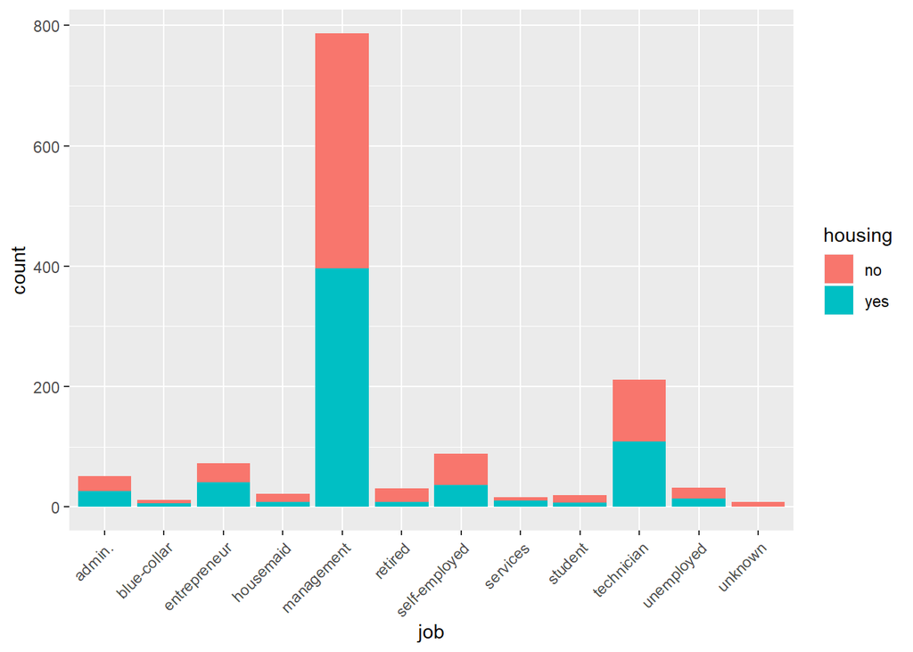

```r
finding_1<-dplyr::filter(bank,education =="tertiary")
ggplot(finding_1)+geom_bar(mapping = aes(x = job,fill=housing))+theme(axis.text.x = element_text(angle = 45, hjust = 1))
```

# Finding #2

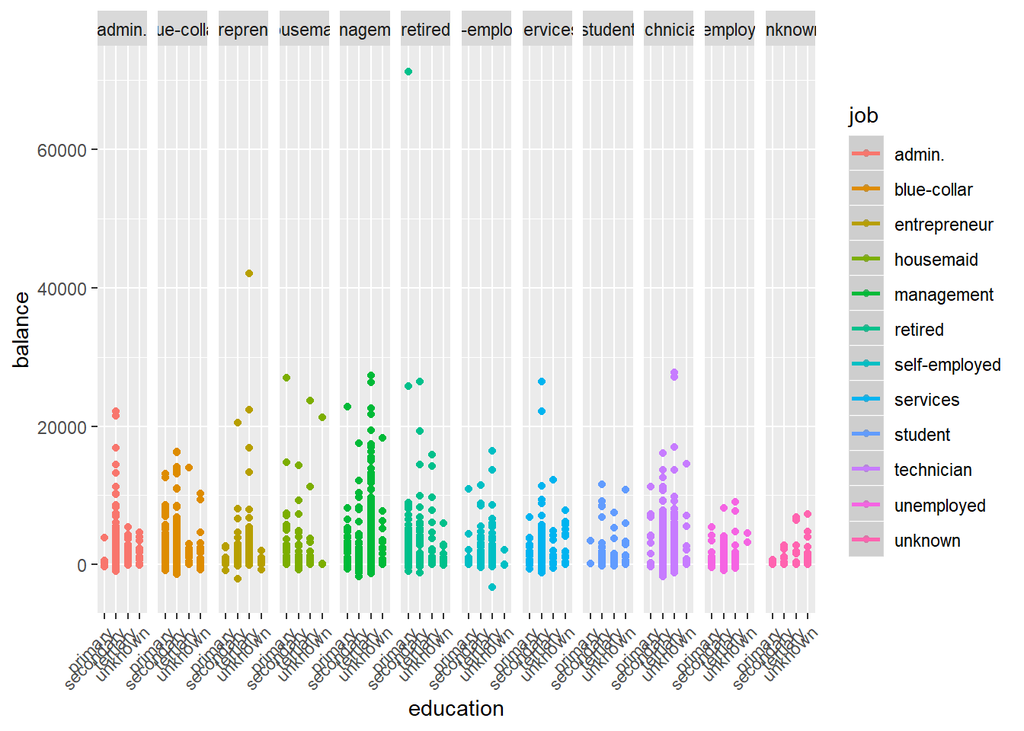

```r
ggplot(bank, aes(education, balance, color = job)) +
    geom_point() + geom_smooth(method='loess') +
    facet_grid(. ~ job)+theme(axis.text.x = element_text(angle = 45, hjust = 1))
```

# Finding #3

- Younger people are more likely to be higher educated than the elder people.

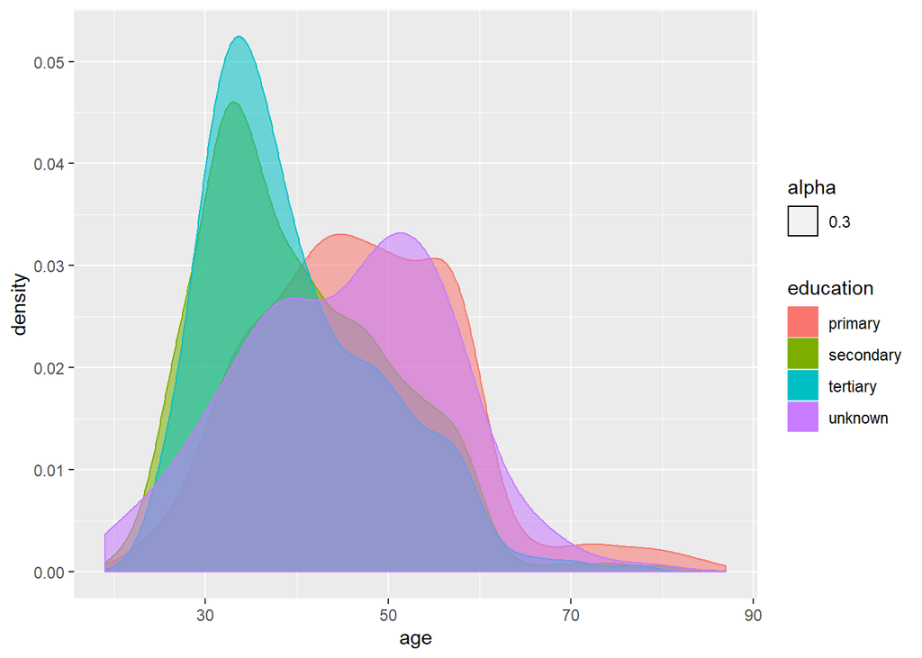

```r
ggplot(bank, aes(age, color = education, fill = education, alpha = 0.3)) +
          geom_density()
```

# Finding #4

- Most customers are in their 30s, 40s and 50s.
- Most customers have secondary education background.
- People who are in their 40s and 50s are likely to have relatively higher balance, among which the tertiary educated people would hold even higher balance.

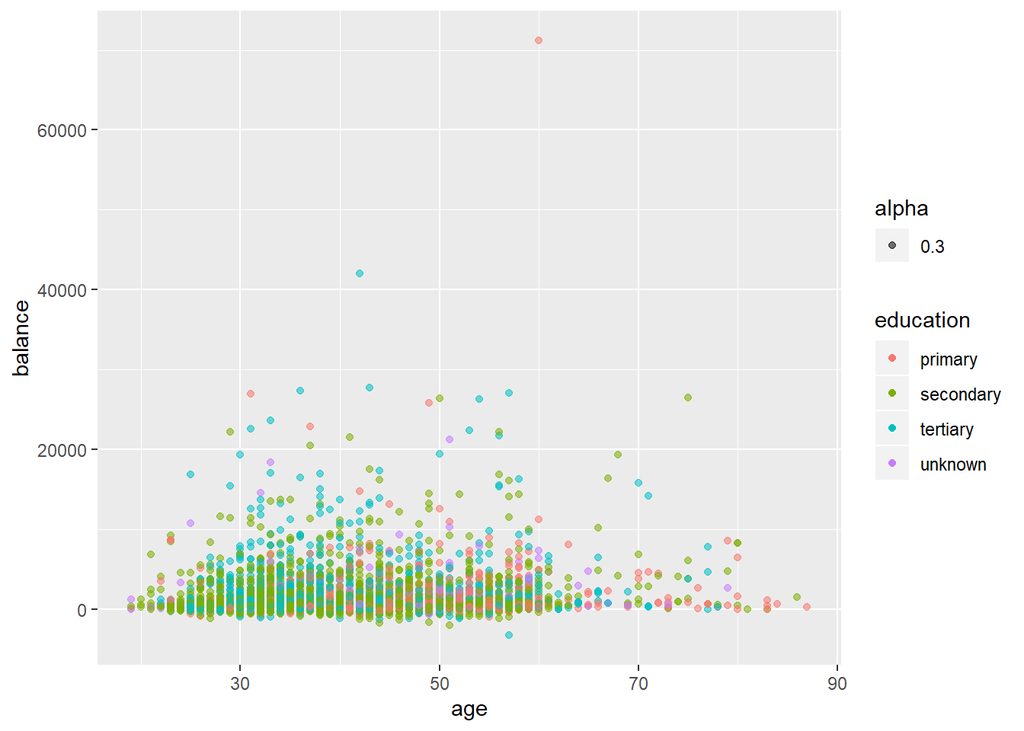

```r
ggplot(bank, aes(age, color = education, fill = education, alpha = 0.3)) +geom_point(aes(age, balance, group = contact))
```

# Finding #5

- Managers and the blue-collar tend to have long duration.
- Students has the highest single rate followed by technicians.
- Customers in Service and admin have high divorced rate.

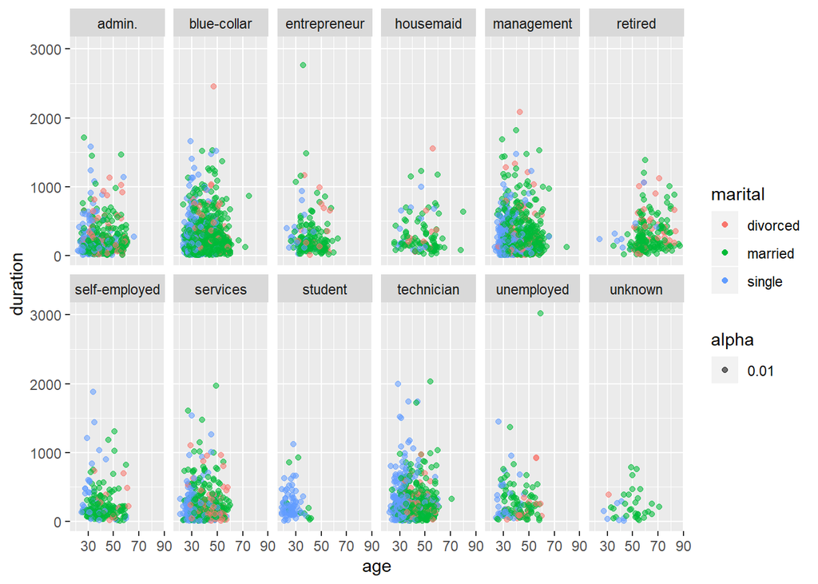

```r
ggplot(data = bank) + geom_point(mapping = aes(x = age, y = duration,color=marital,alpha=0.01)) + facet_wrap(.~job, nrow = 2)
```

# Finding #6

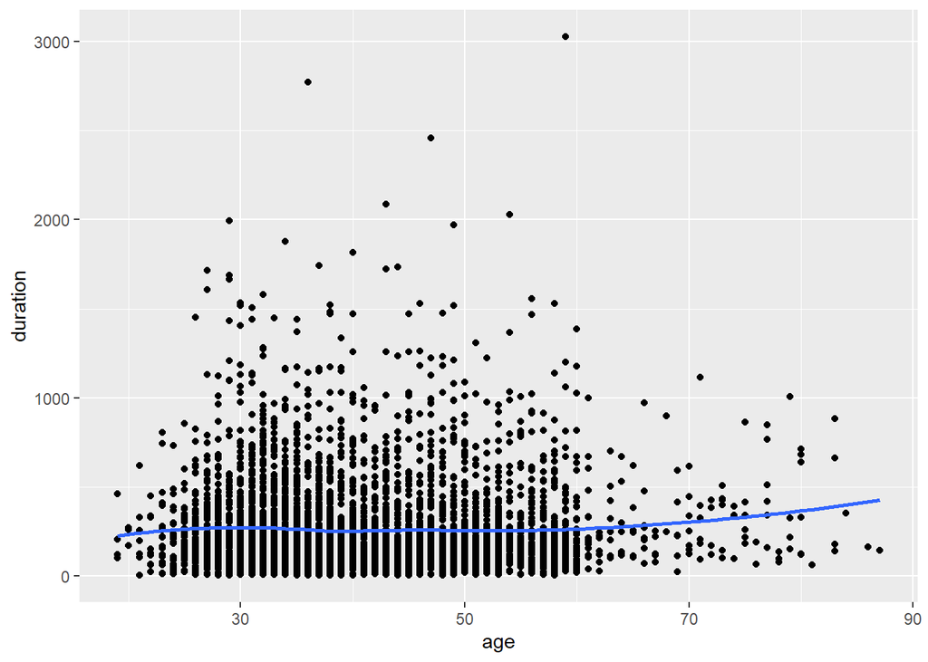

```r
ggplot(bank, aes(age, duration)) +
          geom_point() +
geom_smooth(method = "loess", se = FALSE)
```

# Finding #7

- Most people eleder than 60 do not have house.
- People are likely to have house between 30 to 40.

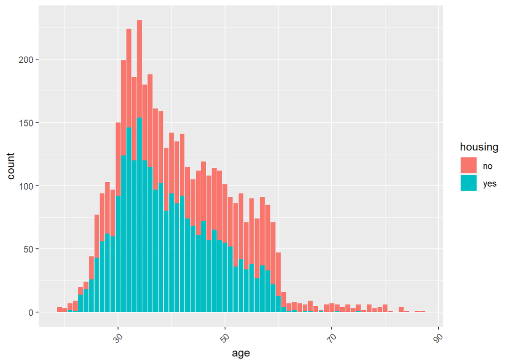

```r
ggplot(bank)+geom_bar(mapping = aes(x = age,fill=housing))+theme(axis.text.x = element_text(angle = 45, hjust = 1))
```

# Finding #8

- students are tend to hold lowest balance and have the highest single rate.
- Most divorced people are likely to have low balance.

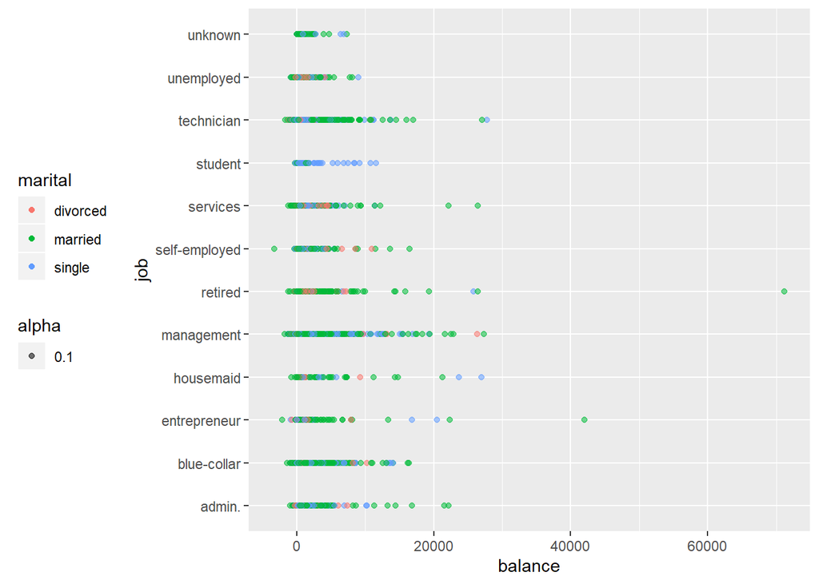

```r
ggplot(bank, aes(x = job, y = balance, color = marital,alpha=0.1)) + geom_point() +
theme(legend.position="left") +
coord_flip()
```

# Finding #9

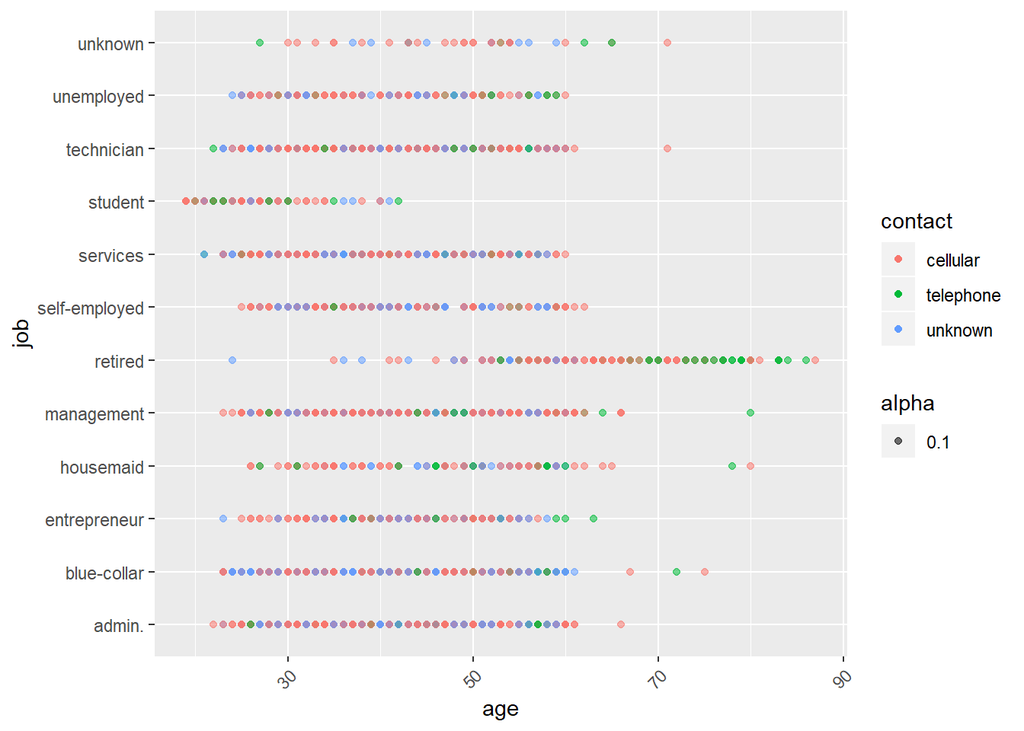

```r
ggplot(bank) +geom_point(aes(age, job, color = contact,alpha=0.1))+theme(axis.text.x = element_text(angle = 45, hjust = 1))
```

# Finding #10

- Compared with other age groups, people in their 50s are likely to have loan.
- People who have loan tend to have less balance.

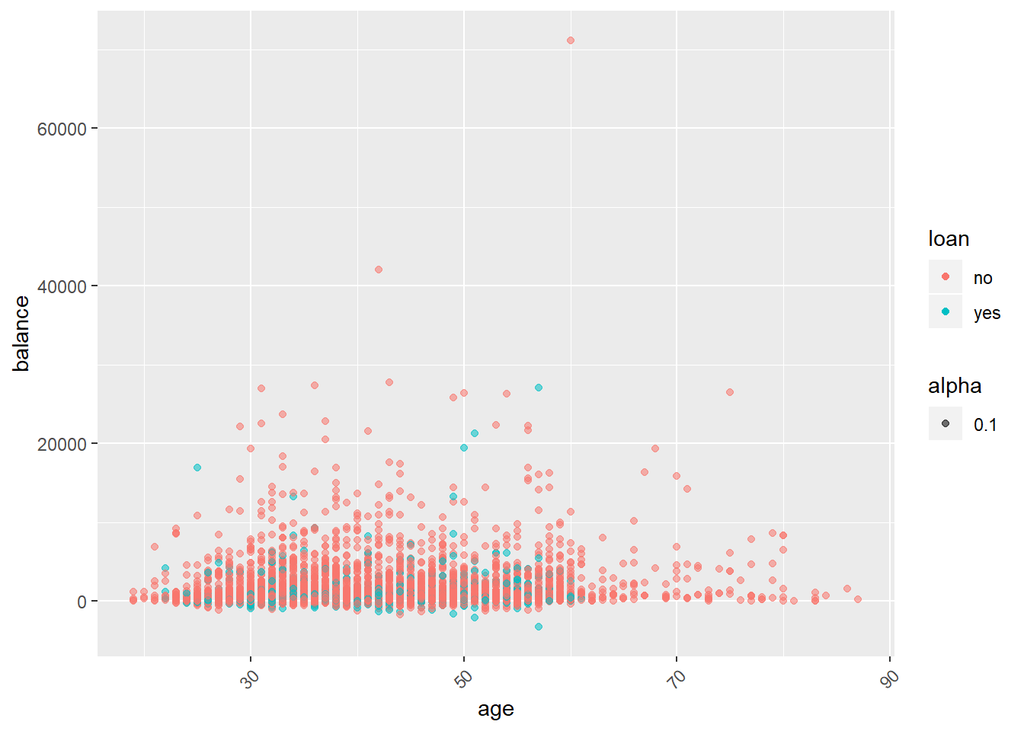

```r
ggplot(bank) +geom_point(aes(age, balance, color = loan,alpha=0.1))+theme(axis.text.x = element_text(angle = 45, hjust = 1))
```